# Woodbury Heights Public School District — NJ School Data Almanac – NJ District Profiles

NJ School Data Almanac

Woodbury Heights Public School District

GLOUCESTER COUNTY · TRADITIONAL PUBLIC DISTRICT · DFG FG · 238 STUDENTS (2026)

238

Students

53.8%

Gr 3-8 ELA

11.5%

Chronically absent

$15,647

Per pupil

*7 things the data says about Woodbury Heights Public School District. Every figure is computed from New Jersey Department of Education data via the njschooldata package — nothing is estimated. Comparisons use District Factor Group (DFG) peers (89 districts in DFG FG).*

No. 1 ACHIEVEMENT

## Woodbury Heights Math Proficiency Cratered to 33% in 2022, Then Clawed Back 16 Points by 2024

The pandemic knocked the K-6 district’s NJSLA math proficiency down more than 20 points, and most of that loss has since been recovered.

No number in Woodbury Heights moved more violently through the pandemic than math proficiency. On the NJSLA exams for grades 3-8, 54.1 percent of the district’s students scored proficient or above in 2019. When testing resumed in 2022, that figure had collapsed to 32.9 percent — a drop of 21.2 percentage points, meaning roughly two-thirds of tested students were no longer hitting grade level in math.

The recovery has been real but incomplete. Math proficiency climbed to 43.8 percent in 2023 and 48.5 percent in 2024, recovering about 16 of the 21 points lost. ELA held up far better through the same stretch, dipping only 8.1 points from 55.0 percent in 2019 to 46.9 percent in 2022 before rebounding to 53.8 percent in 2024 — essentially back to its pre-pandemic level.

The contrast is the story: reading bounced back fully while math, the harder subject to recover remotely, still sits below its 2019 mark. With 2024 math at 48.5 percent, the district has closed most of the gap. Will the next round of scores carry math back above its pre-COVID 54 percent, or has recovery stalled a few points short?

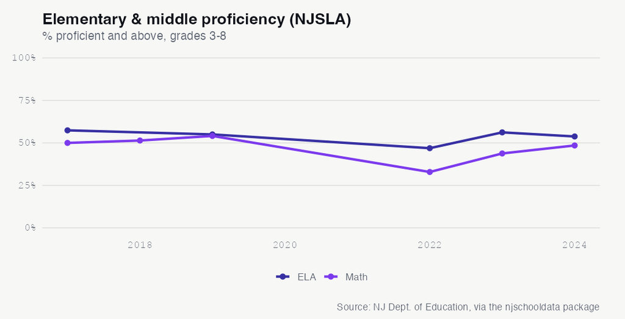

See the underlying data ›

No. 2 EQUITY

## Girls Out-Read Boys by 19 Points on Woodbury Heights’ 2024 Reading Test

On the 2024 NJSLA ELA exam, 62.8 percent of girls scored proficient versus 43.5 percent of boys — a gap that straddles the district’s overall average.

Woodbury Heights’ 2024 reading results split sharply by gender. Among girls in grades 3-8, 62.8 percent scored proficient or above on the NJSLA ELA exam, compared with 43.5 percent of boys — a gap of 19.3 percentage points. The district’s overall ELA proficiency of 53.8 percent sits between the two, pulled up by girls and down by boys.

A reading gap favoring girls is common across New Jersey and the country, but the size here is striking: fewer than half of the district’s boys reached proficiency while nearly two-thirds of girls did. White students, the largest group the data breaks out, posted 60.0 percent proficiency, also above the district average.

In a district enrolling only a couple hundred children, a single grade’s cohort can tilt these subgroup figures, so one year is not a trend. But a near-20-point gender split in reading is the kind of signal an elementary board can act on early. Is the 2024 gap a one-year artifact of small cohorts, or a persistent pattern in how the district’s boys are learning to read?

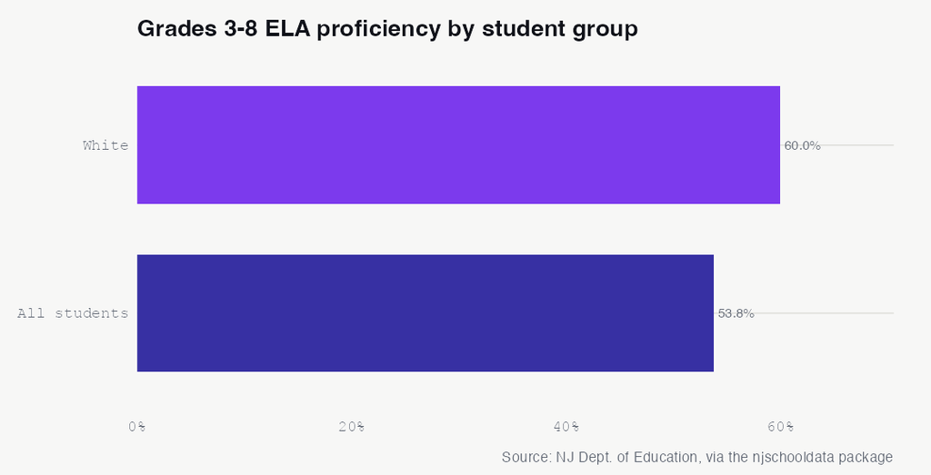

See the underlying data ›

No. 3 FINANCE

## Woodbury Heights Spends $15,647 Per Pupil — About $3,300 Below Its Peer-Group Median

The K-6 district’s per-pupil spending sits in the 8th percentile among 89 demographically similar New Jersey districts.

Among the 89 districts that New Jersey groups with Woodbury Heights by District Factor Group FG, few spend less per student. The district reported $15,647 per pupil in 2024, placing it in the 8th percentile of its peer group, where the median district spent $18,979 — a gap of more than $3,000 for every child enrolled.

That thrift is long-standing, not a one-year squeeze. Per-pupil spending has risen only 10.7 percent over a decade, from $14,134 in 2014 to $15,647 in 2024, even as average daily enrollment grew from 212 to 256 students over the same span. Where the money does go is heavily weighted toward the classroom: 68.4 percent of 2025 spending went to classroom instruction, with 12.3 percent to support services, 9.9 percent to administration, and 8.8 percent to plant operations.

For a district this small, fixed costs are hard to spread across few students, which usually pushes per-pupil figures up, not down. So how is Woodbury Heights holding its spending so far below peers — and what would families gain, or give up, if it moved toward the FG median?

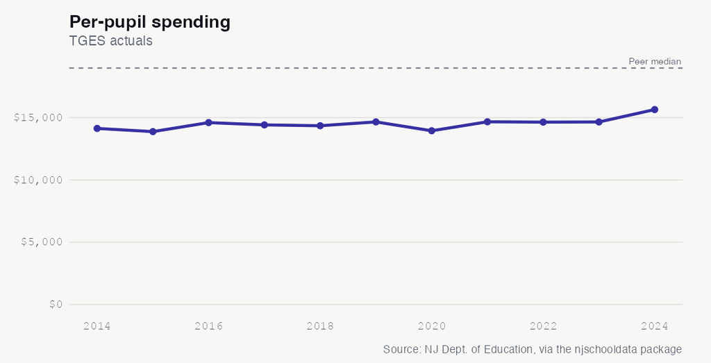

See the underlying data ›

No. 4 DEMOGRAPHICS

## White Enrollment Share Fell From 87% to 75% in Woodbury Heights Since 2015, as Multiracial Students Tripled

A district that was nearly nine-in-ten white a decade ago has grown steadily more diverse, led by a rising multiracial population.

Woodbury Heights looks measurably different than it did a decade ago. In 2015, white students made up 87.3 percent of enrollment; by 2026 that share had fallen 12.1 percentage points to 75.2 percent. The change has been gradual and consistent rather than a single sharp break, with the white share sliding most years through 2024.

The fastest-growing group is multiracial students, who rose from 2.7 percent of enrollment in 2015 to 8.8 percent in 2026 — more than tripling their share. Hispanic enrollment climbed from 7.7 percent to a peak of 12.2 percent in 2023 before easing to 9.2 percent, and the Black share, which spiked to 8.1 percent in 2020, settled at 4.2 percent by 2026. Asian enrollment, long under one percent, reached 2.1 percent in 2026.

In a district enrolling only 238 students, a single family moving in or out can swing a subgroup’s percentage, so year-to-year wobbles are expected. But the decade-long direction is unmistakable. Will the diversifying trend continue, and is the district’s staffing and curriculum keeping pace with a student body that no longer resembles the one it served in 2015?

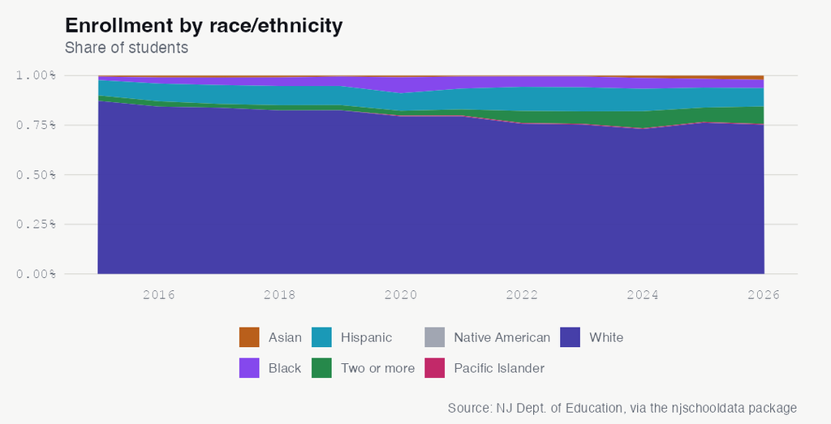

See the underlying data ›

No. 5 ATTENDANCE

## Chronic Absenteeism in Woodbury Heights Nearly Doubled Since 2019, Reaching 11.5%

The share of students who are chronically absent jumped from 6.8 percent before the pandemic to 11.5 percent in 2024, landing just above the peer median.

Before the pandemic, Woodbury Heights had relatively strong attendance: in 2019, 6.8 percent of students were chronically absent, meaning they missed at least 10 percent of school days. By 2024 that figure had climbed to 11.5 percent — close to double the pre-COVID rate.

The rise was not a straight line. The chronic absenteeism rate actually dipped to 5.2 percent in 2021, a year of disrupted attendance counting, then surged to 11.2 percent in 2022 and a peak of 12.8 percent in 2023 before easing slightly to 11.5 percent in 2024. That latest figure sits just above the peer median of 11.3 percent, so Woodbury Heights’ elevated absenteeism mirrors a broad regional pattern rather than standing out as an outlier.

For an elementary district, early attendance habits shape later outcomes, and a doubling in five years is the kind of shift boards watch closely. With the rate now slightly off its 2023 peak, is Woodbury Heights at the start of a recovery toward its 2019 baseline, or has chronic absence settled into a new normal?

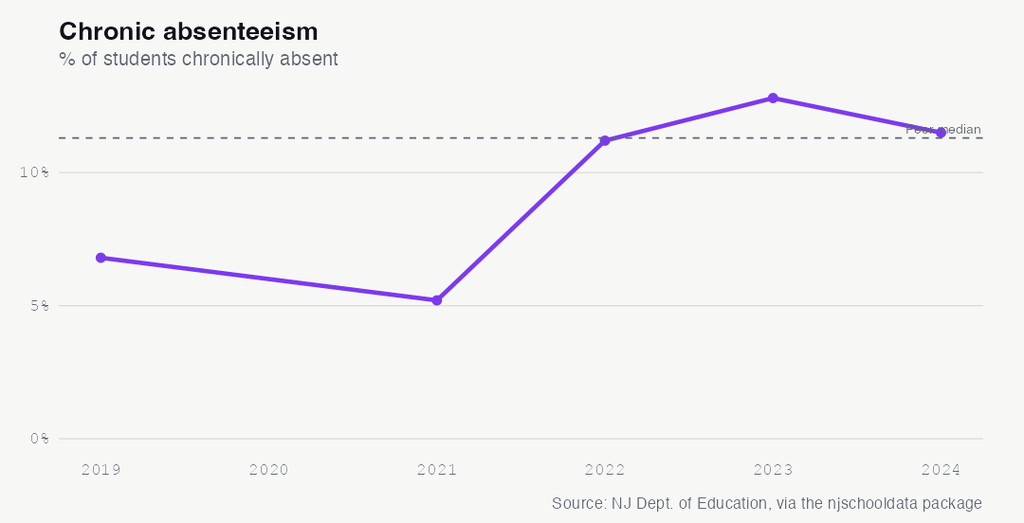

See the underlying data ›

No. 6 ENROLLMENT

## Woodbury Heights Enrollment Swung From 256 to 238 in Two Years After Hitting a Decade High

The tiny district peaked at 256 students in 2024, then lost 18 over the next two years — the kind of volatility that comes with serving fewer than 260 children.

Enrollment in Woodbury Heights has been on a roller coaster. After bottoming out at 210 students in 2017, the district climbed to a decade-high 256 in 2024 — then slid to 248 in 2025 and 238 in 2026, a two-year loss of 18 students, or about 7 percent.

The pandemic years were especially turbulent. Enrollment jumped 19 students to 248 in 2020, fell 19 the next year to 229, then rebounded by 18 to 247 in 2022. Across the full 2015-to-2026 window, the district grew on net by 18 students, from 220 to 238, an 8.2 percent increase despite all the year-to-year noise.

When a district serves only a couple hundred children, a single grade cohort graduating out or a handful of families relocating can move the total by several percentage points. That makes long-range planning hard. Is the recent two-year decline the leading edge of a sustained drop, or just another dip in a pattern that has repeatedly snapped back?

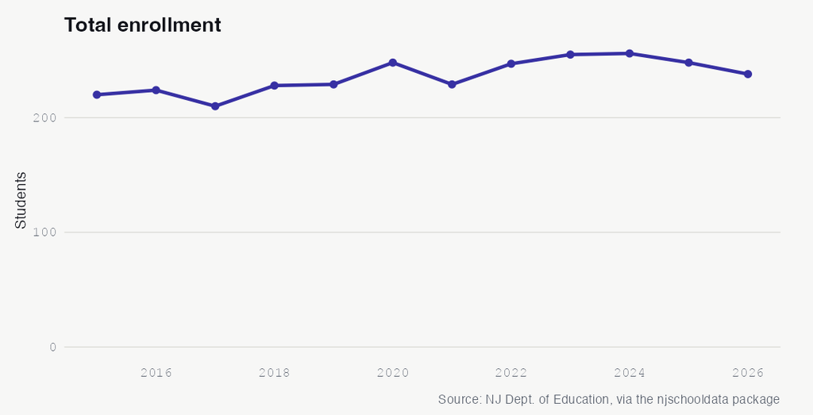

See the underlying data ›

No. 7 EQUITY

## Free-and-Reduced Lunch Eligibility in Woodbury Heights Swung From 26% to 9% and Back to 21%

The share of students qualifying for subsidized meals has whipsawed over the decade, from a 2020 high of 26.3 percent to a 2023 low of 9.1 percent.

One of the most volatile numbers in Woodbury Heights is its measure of student economic need. The share of students eligible for free or reduced-price lunch peaked at 26.3 percent in 2020, then plunged to 9.1 percent by 2023 — a swing of 17 percentage points in three years — before climbing back to 20.6 percent in 2026.

The 2026 figure of 49 students, or 20.6 percent, is almost exactly where the district started in 2015, when 46 students (20.9 percent) qualified. The intervening years tell a less stable story, with dips to 12.7 percent in 2019 and the 9.1 percent trough in 2023. Such sharp moves in a district of roughly 240 students can reflect a handful of families’ circumstances changing, as well as shifts in how meal eligibility is reported.

Meanwhile, the district recorded essentially no English learners for most of the decade — zero through 2024 — before two students were identified in 2025 and 2026, the first in the data. As economic-need counts settle back near their 2015 level, will the recent uptick in free-and-reduced eligibility hold, or resume its swing?

See the underlying data ›

## The Almanac

The full longitudinal record behind the stories above. Every number a reader can check.

### Enrollment (total)

| year | students | yoy | yoy_pct |
| --- | --- | --- | --- |
| 2015 | 220 | NA | NA |
| 2016 | 224 | 4 | 1.8 |
| 2017 | 210 | -14 | -6.2 |
| 2018 | 228 | 18 | 8.6 |
| 2019 | 229 | 1 | 0.4 |
| 2020 | 248 | 19 | 8.3 |
| 2021 | 229 | -19 | -7.7 |
| 2022 | 247 | 18 | 7.9 |
| 2023 | 255 | 8 | 3.2 |
| 2024 | 256 | 1 | 0.4 |
| 2025 | 248 | -8 | -3.1 |
| 2026 | 238 | -10 | -4 |

### Demographic share (%) by year

| end_year | white | black | hispanic | asian | native_american | pacific_islander | multiracial |
| --- | --- | --- | --- | --- | --- | --- | --- |
| 2015 | 87.3 | 1.8 | 7.7 | 0.5 | 0 | 0 | 2.7 |
| 2016 | 84.4 | 3.1 | 8.9 | 0.9 | 0 | 0 | 2.7 |
| 2017 | 83.8 | 3.8 | 9.5 | 1 | 0 | 0 | 1.9 |
| 2018 | 82.5 | 4.4 | 9.6 | 0.9 | 0 | 0 | 2.6 |
| 2019 | 82.5 | 4.8 | 9.6 | 0.4 | 0 | 0 | 2.6 |
| 2020 | 79.4 | 8.1 | 8.9 | 0.8 | 0 | 0.4 | 2.4 |
| 2021 | 79.5 | 6.1 | 10.5 | 0.4 | 0 | 0.4 | 3.1 |
| 2022 | 75.7 | 5.3 | 12.1 | 0.4 | 0 | 0.4 | 6.1 |
| 2023 | 75.3 | 5.5 | 12.2 | 0.4 | 0 | 0.4 | 6.3 |
| 2024 | 73 | 5.5 | 11.3 | 1.2 | 0 | 0.4 | 8.6 |
| 2025 | 76.2 | 4.4 | 10.1 | 1.6 | 0 | 0.4 | 7.3 |
| 2026 | 75.2 | 4.2 | 9.2 | 2.1 | 0 | 0.4 | 8.8 |

### Special populations (LEP, FRL)

| end_year | subgroup | students | pct |
| --- | --- | --- | --- |
| 2015 | lep | 0 | 0.0 |
| 2015 | free_reduced_lunch | 46 | 20.9 |
| 2016 | lep | 0 | 0.0 |
| 2016 | free_reduced_lunch | 51 | 22.8 |
| 2017 | lep | 0 | 0.0 |
| 2017 | free_reduced_lunch | 47 | 22.4 |
| 2018 | lep | 0 | 0.0 |
| 2018 | free_reduced_lunch | 43 | 18.9 |
| 2019 | lep | 0 | 0.0 |
| 2019 | free_reduced_lunch | 29 | 12.7 |
| 2020 | lep | 0 | 0.0 |
| 2020 | free_reduced_lunch | 65 | 26.3 |
| 2021 | lep | 0 | 0.0 |
| 2021 | free_reduced_lunch | 54 | 23.6 |
| 2022 | lep | 0 | 0.0 |
| 2022 | free_reduced_lunch | 27 | 10.9 |
| 2023 | lep | 0 | 0.0 |
| 2023 | free_reduced_lunch | 23 | 9.1 |
| 2024 | lep | 0 | 0.0 |
| 2024 | free_reduced_lunch | 40 | 15.6 |
| 2025 | lep | 2 | 0.8 |
| 2025 | free_reduced_lunch | 49 | 19.7 |
| 2026 | lep | 2 | 0.8 |
| 2026 | free_reduced_lunch | 49 | 20.6 |

### NJSLA grades 3-8 proficiency (% proficient+, enrollment-weighted across grades)

| testing_year | test_name | prof |
| --- | --- | --- |
| 2017 | ela | 57.4 |
| 2017 | math | 50.0 |
| 2018 | math | 51.4 |
| 2019 | ela | 55.0 |
| 2019 | math | 54.1 |
| 2022 | ela | 46.9 |
| 2022 | math | 32.9 |
| 2023 | ela | 56.2 |
| 2023 | math | 43.8 |
| 2024 | ela | 53.8 |
| 2024 | math | 48.5 |

### NJSLA ELA proficiency by subgroup (2024, grades 3-8)

| subgroup | prof |
| --- | --- |
| female | 62.8 |
| white | 60.0 |
| total_population | 53.8 |
| male | 43.5 |
| non_ed | NA |

### Chronic absenteeism (% chronically absent)

| year | chronic_pct |
| --- | --- |
| 2019 | 6.8 |
| 2021 | 5.2 |
| 2022 | 11.2 |
| 2023 | 12.8 |
| 2024 | 11.5 |

### Disciplinary removals

[output not shown]

### Police notifications (incident counts)

| year | violence | weapons | vandalism | substances | hib | other |
| --- | --- | --- | --- | --- | --- | --- |
| 2019 | 0 | 0 | 0 | 0 | 0 | 0 |
| 2020 | NA | NA | NA | NA | NA | NA |
| 2021 | NA | NA | NA | NA | NA | NA |
| 2022 | 0 | 1 | 0 | 0 | 0 | 0 |
| 2023 | 0 | 0 | 0 | 0 | 0 | 0 |
| 2024 | 0 | 0 | 0 | 0 | 0 | 0 |

### HIB (harassment/intimidation/bullying) investigations

| end_year | alleged | confirmed |
| --- | --- | --- |
| 2019 | 2 | 0 |
| 2020 | 0 | 0 |
| 2021 | 0 | 0 |
| 2022 | 0 | 1 |
| 2023 | 2 | 0 |
| 2024 | 0 | 0 |

### Special education (raw rows; inspect for classification rate)

| end_year | district_id |
| --- | --- |
| 2024 | 5870 |

### Per-pupil spending (TGES actuals)

| year | per_pupil | rank | ade |
| --- | --- | --- | --- |
| 2014 | 14134 | 27 | 212 |
| 2015 | 13879 | 23 | 220 |
| 2016 | 14601 | 24 | 224 |
| 2017 | 14418 | 19 | 226 |
| 2018 | 14350 | 17 | 231 |
| 2019 | 14656 | 15 | 235 |
| 2020 | 13947 | 9 | 245 |
| 2021 | 14666 | 10 | 230 |
| 2022 | 14639 | 6 | 249 |
| 2023 | 14652 | 4 | 254 |
| 2024 | 15647 | 5 | 256 |

### Spending composition shares (2025)

| classroom_share | support_services_share | administration_share | plant_ops_share | food_service_share | extracurricular_share | equipment_share |
| --- | --- | --- | --- | --- | --- | --- |
| 68.4 | 12.3 | 9.9 | 8.8 | NA | 0.7 | 0 |

### Staffing ratios

| end_year | student_teacher_district | student_admin_district | student_counselor_district | student_nurse_district |
| --- | --- | --- | --- | --- |
| 2024 | 9:1 | 128:1 | 256:1 | 256:1 |

Back to top